# imagine-intro

```r
library(imagine)
```

# imagine

**IMAGing engINE, Tools for Application of Image Filters to Data Matrices**

The **imagine** package streamlines the process of applying image-filtering algorithms to numeric data matrices. It employs efficient median-filter and 2D-convolution algorithms implemented in Rcpp (C++), enabling rapid processing of large datasets.

## Installation

For installing `imagine`, as follows:

```r
install.packages("imagine")
```

## Engines

The **imagine** package employs C++-based algorithms, designated as ‘engines,’ crafted with [**Rcpp**](https://cran.r-project.org/package=Rcpp) and [**RcppArmadillo**](https://cran.r-project.org/package=RcppArmadillo), to expedite the application of image filters. These engines significantly enhance the performance of filtering operations, ensuring efficient processing of large datasets. As of version 2.1.0, **imagine** incorporates the following engines:

- Engine 1: The basic 2D-convolution operation that involves multiplying a kernel by the neighborhood of each cell and summing the results.
- Engine 2: it performs the same convolution operation as Engine 1 but returns the position specified by the `probs` parameter.
- Engine 3: It uses the `radius` argument to extract the values of squared neighborhood ($radius \times radius$) and calculates the mean.
- Engine 4: It uses the `radius` argument to extract the values of squared neighborhood ($radius \times radius$) and returns the position indicated by the parameter `probs`
- Engine 5: Contextual Median Filter described in Belkin and O’Reilly (2009) paper http://dx.doi.org/10.1016/j.jmarsys.2008.11.018.
- Engines 6 and 7: Gradient filters proposed by Agenbag et al. (2003) paper https://doi.org/10.1016/j.pocean.2003.07.004.

Since version 2.0.0, `radius` could accept 2 values to define the number of rows and columns respectively of the window.

## Main functions

There are 5 main functions and 2 wrappers:

### Convolution functions

```r
# Build kernels
# Kernel 1: For bottom edge recognition
kernel1 <- matrix(c(-1, -2, -1,
                     0,  0,  0,
                     1,  2,  1),
                  nrow = 3)

# Kernel 2: Diagonal weighting
kernel2 <- matrix(c(-2, 0, 0,
                     0, 1, 0,
                     0, 0, 2),
                  nrow = 3)

# Apply filters
convolutionExample  <- convolution2D(X = wbImage, kernel = kernel1)
convQuantileExample <- convolutionQuantile(X = wbImage, kernel = kernel2, probs = 0.1)
```

In order to compare results, we will plot both data (original and filtered) using `image` function, as shows in figures 1 and 2.

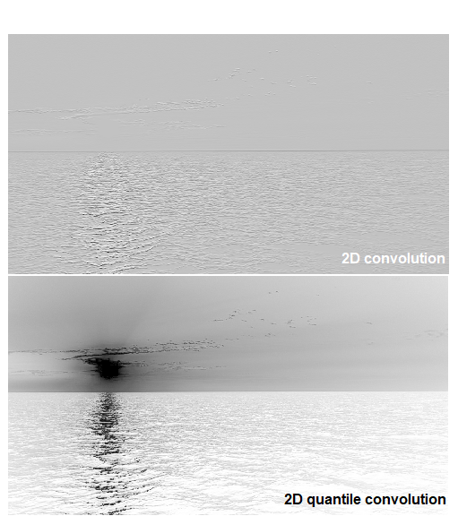

Figure 1: 2D vs 2D quantile convolutions

### Median-filter asociated functions

```r
# Add some noise (NA) to the image (matrix)
set.seed(7)
naIndex <- sample(x       = seq(prod(dim(myMatrix))),
                  size    = as.integer(0.4*prod(dim(myMatrix))),
                  replace = FALSE)
myMatrix[naIndex] <- NA

# Build kernel
radius <- 3

# Apply filters
meanfilterExample     <- meanFilter(X = myMatrix, radius = radius)
quantilefilterExample <- quantileFilter(X = myMatrix, radius = radius, probs = 0.1)
medianfilterExample   <- medianFilter(X = myMatrix, radius = radius)
```

**Original and Filtered**

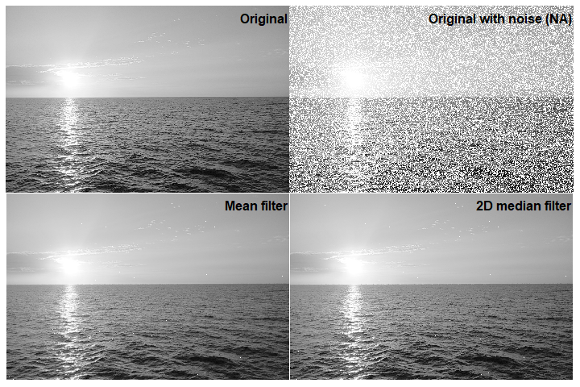

Figure 2: Basic filters comparison

## Kernel application

In the field of image processing, one of the tools most commonly used are the **convolutions**, which consist of operations between two arrays: The array of image data (as a big matrix) and kernels (as small matrices) which weighs each pixel values by the values of its corresponding neighborhood. Different kernels produce different effects, for instance: blur, shifted images (right, left, up or down), sharpening, etc. The users must be cautious with the size of the kernel because the larger the radius, the more pixels remain unanalyzed at the edges.

Besides, every function of **imagine** allows the recursive running of a filter by the using of `times` argument.

[figure not shown]

Figure 3: Filters with several time settings

```r
medianFilter(X = wbImage, radius = 5, times = 50)
```

## Filters based on published articles

Since its version 2.1.0, `imagine` includes two functions that implement the algorithms of two papers related to the calculation of oceanographic gradients:

- `contextualMF`: Based on pseudocode provided in Belkin, I. M., & O’Reilly, J. E. (2009). An algorithm for oceanic front detection in chlorophyll and SST satellite imagery. Journal of Marine Systems, 78(3), 319-326. https://doi.org/10.1016/j.jmarsys.2008.11.018
- `agenbagFilters`: Based on Agenbag, J. J., Richardson, A. J., Demarcq, H., Freon, P., Weeks, S., & Shillington, F. A. (2003). Estimating environmental preferences of South African pelagic fish species using catch size- and remote sensing data. Progress in Oceanography, 59(2-3), 275-300. https://doi.org/10.1016/j.pocean.2003.07.004

Although both functions are available and can be executed directly from **imagine**, it is recommended to use them through the [**grec**](https://cran.r-project.org/package=grec) package.